# Plotting

Esko

04.01.2016

Quite often students and even researchers think that the ultimate goal of data analysis is to get out some small p-values. Later in this course, we will again demonstrate why this is actually simply wrong and silly.

Instead, it is much better to think that the goal of the data analysis is to understand your data and to visualize your results. P-value testing is just an additional check that your results are not very likely just due to random variation.

R has a plenty of datasets included, which can be used for demonstrations. These datasets can be loaded using the function data.

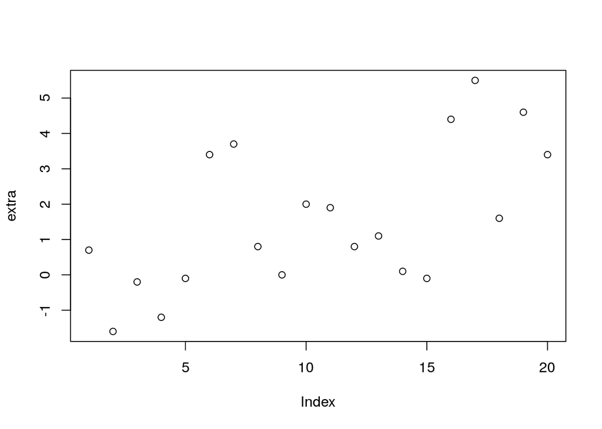

```r
data(sleep)

attach(sleep)
plot(extra)
```

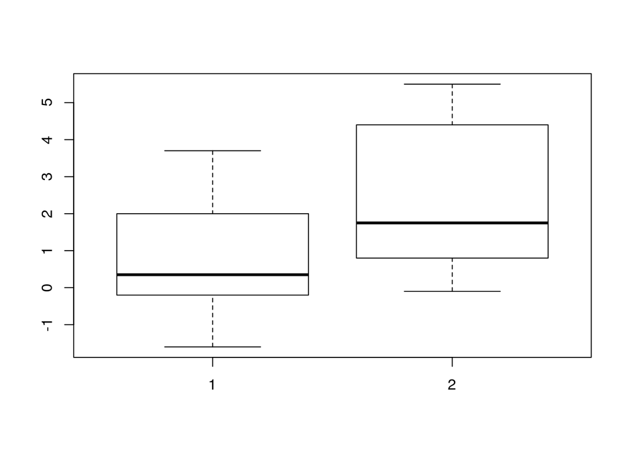

```r
plot(group, extra)
```

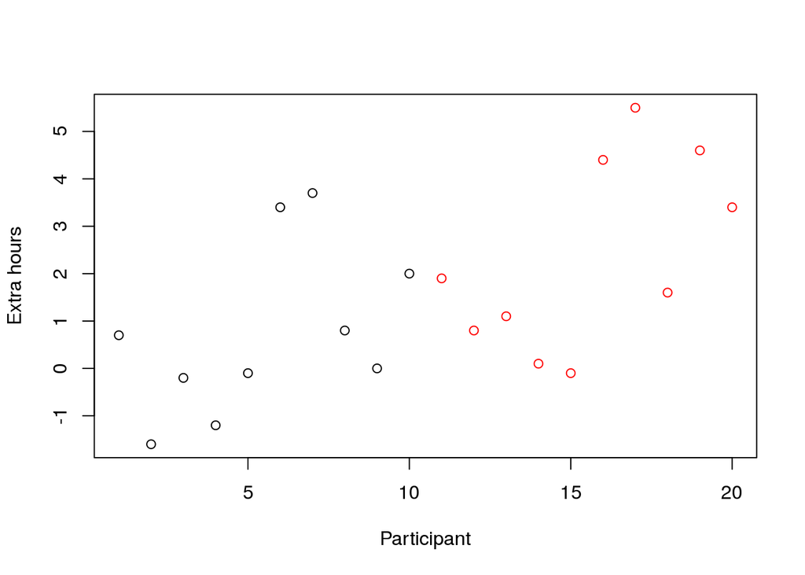

```r
plot(extra, col=group, xlab="Participant", ylab="Extra hours")
```

```r
detach(sleep)
```

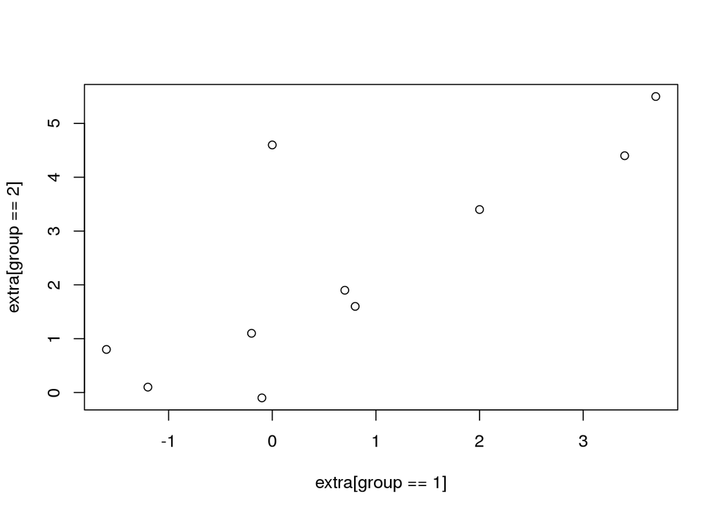

```r
with(sleep, plot(extra[group == 1],
                 extra[group == 2]))
```

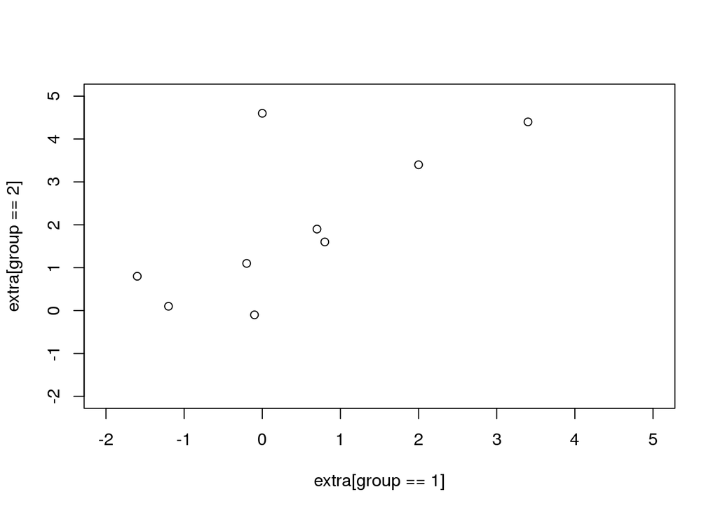

```r
with(sleep, plot(extra[group == 1],
                 extra[group == 2],
                 xlim=c(-2, 5), ylim=c(-2, 5)))
```

```r
with(sleep, t.test(extra[group == 1],
                   extra[group == 2],
                   paired=TRUE))
```

```
##
##  Paired t-test
##
## data:  extra[group == 1] and extra[group == 2]
## t = -4.0621, df = 9, p-value = 0.002833
## alternative hypothesis: true difference in means is not equal to 0
## 95 percent confidence interval:
##  -2.4598858 -0.7001142
## sample estimates:
## mean of the differences
##                   -1.58
```

It is of course possible to reshape the data to wide format before plotting.

```r
require(reshape2)
```

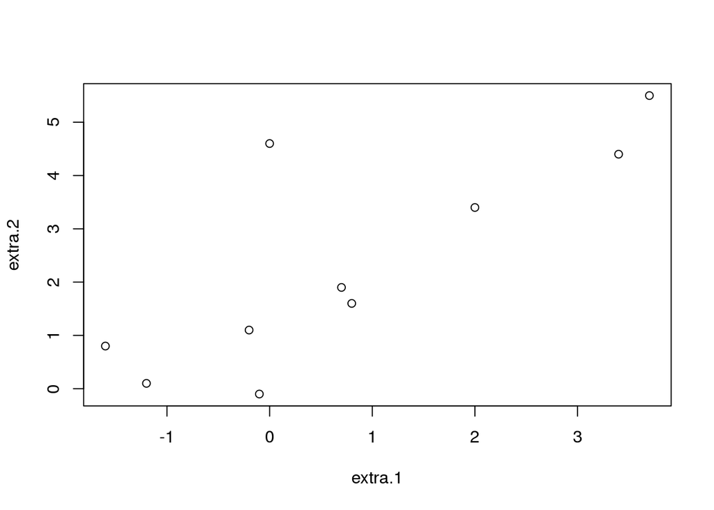

```r
sleep.wide <- reshape(sleep,
                      v.names="extra",
                      timevar="group",
                      idvar="ID",
                      direction="wide")


with(sleep.wide, plot(extra.1, extra.2))
```

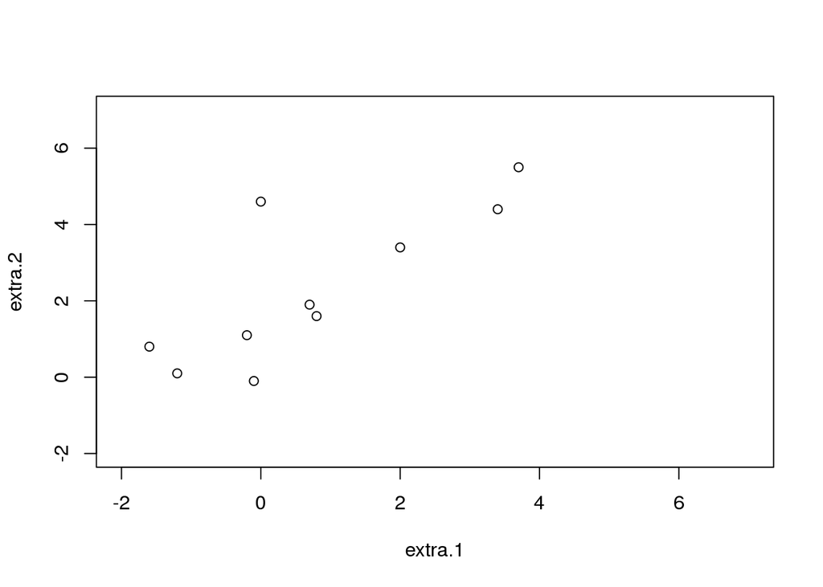

```r
with(sleep.wide, plot(extra.1, extra.2, xlim=c(-2, 7), ylim=c(-2, 7)))
```

```r
sleep.wide$change <- sleep.wide$extra.2 - sleep.wide$extra.1


with(sleep.wide, t.test(extra.1,
                        extra.2,
                        paired=TRUE))
```

```
##
##  Paired t-test
##
## data:  extra.1 and extra.2
## t = -4.0621, df = 9, p-value = 0.002833
## alternative hypothesis: true difference in means is not equal to 0
## 95 percent confidence interval:
##  -2.4598858 -0.7001142
## sample estimates:
## mean of the differences
##                   -1.58
```

## ggplot2 package

The built-in plotting commands in R are powerful, but maybe not the most flexible to use. Luckily, there are many packages which provide alternative ways for plotting data. ggplot2 is one of my favorites.

The basic idea is simple: First you map the variable of the data frame to elements of the plot. Then you “add” different representation or “layers” to the plot.

First, there are example which replicate the previous example using ggplot. However, in order to fully appreaciate its possibility, we need to consider more complex data.

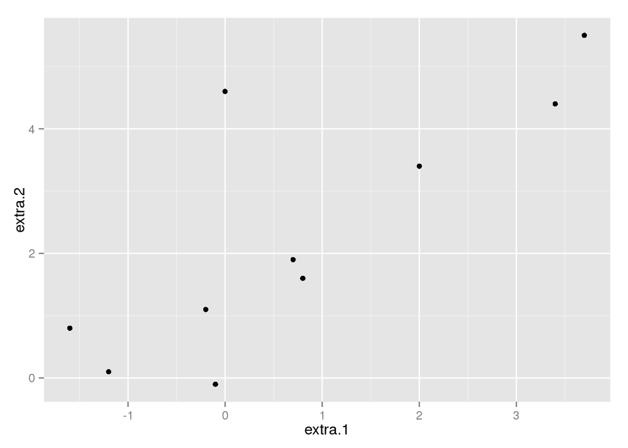

```r
require(ggplot2)
ggplot(sleep.wide, aes(x=extra.1, y=extra.2)) +
  geom_point()
```

First we create the ggplot2 object: we give it the data and then specify the aesthetics. After, that we can specify how it will be displayed.

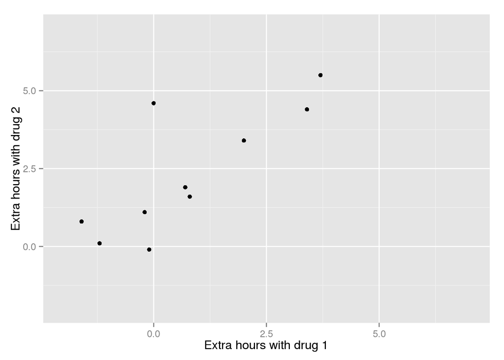

```r
ggplot(sleep.wide, aes(x=extra.1, y=extra.2)) +
  geom_point() +
  xlim(-2, 7) +
  ylim(-2, 7) +
  xlab("Extra hours with drug 1") +
  ylab("Extra hours with drug 2")
```

Ok, let’s now try to have a bit more complex example. First let’s do something which is easy:

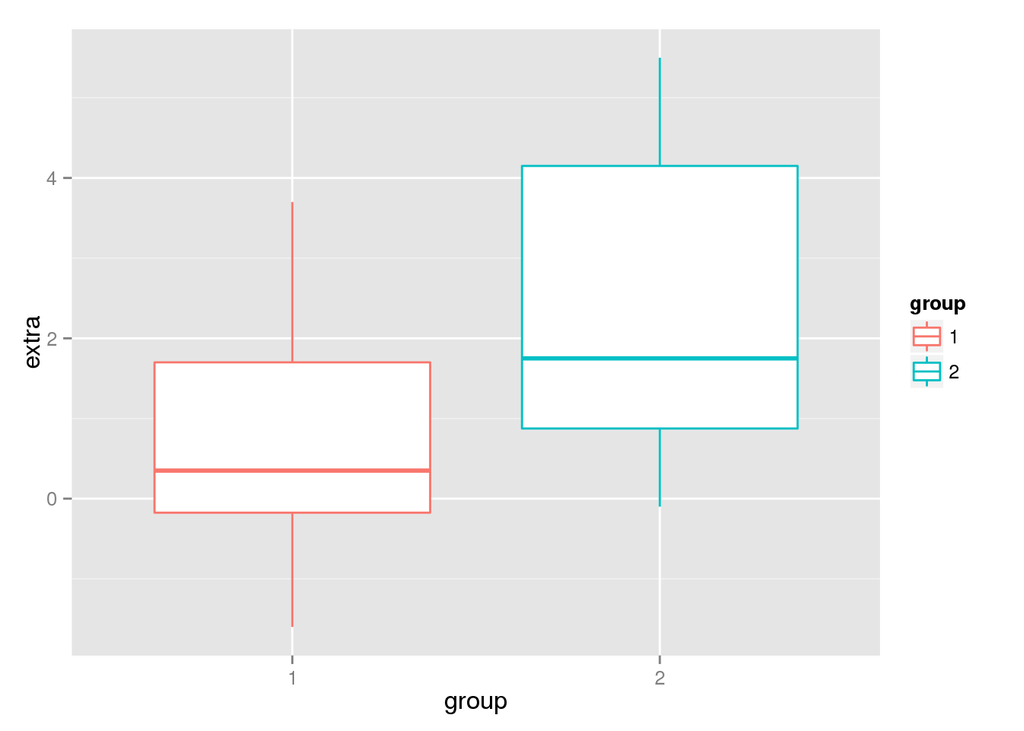

```r
ggplot(sleep, aes(x=group, y=extra, colour=group)) +
  geom_boxplot()
```

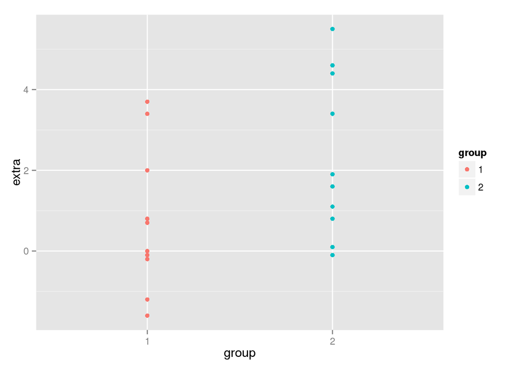

```r
ggplot(sleep, aes(x=group, y=extra, colour=group)) +
  geom_point()
```

It would be also nice to visualize the change using a connecting line between the two measurements from the same participant.

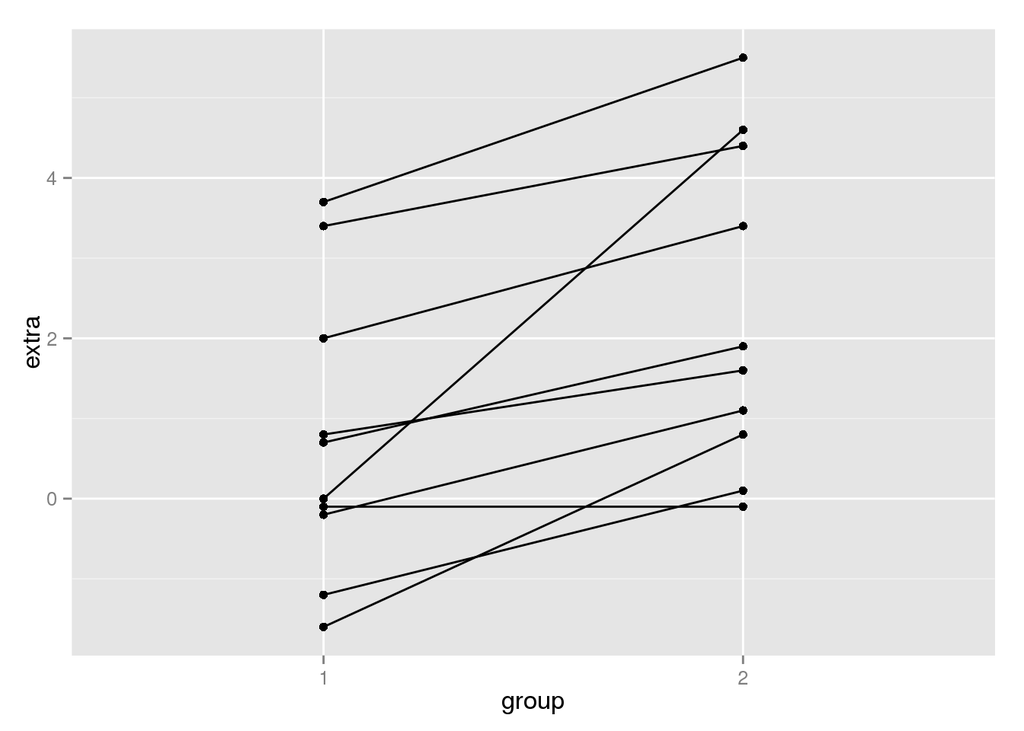

```r
ggplot(sleep, aes(x=group, y=extra)) +
  geom_point() +
  geom_line(aes(group=ID)) # two different uses of group! they are different things here!
```

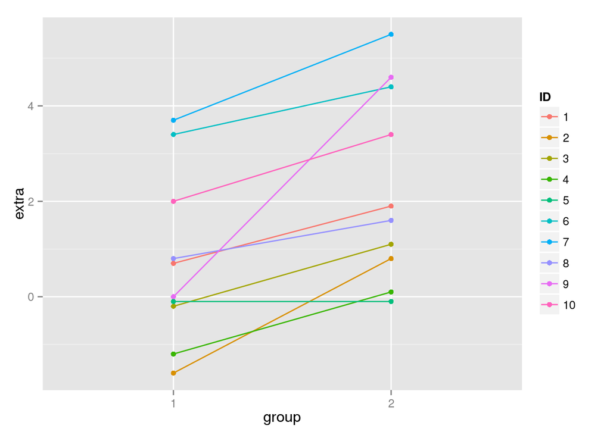

```r
ggplot(sleep, aes(x=group, y=extra, colour=ID)) +
  geom_point() +
  geom_line(aes(group=ID)) # two different uses of group! they are different things here!
```

We could also want to display mean with 95 % and the individual points.

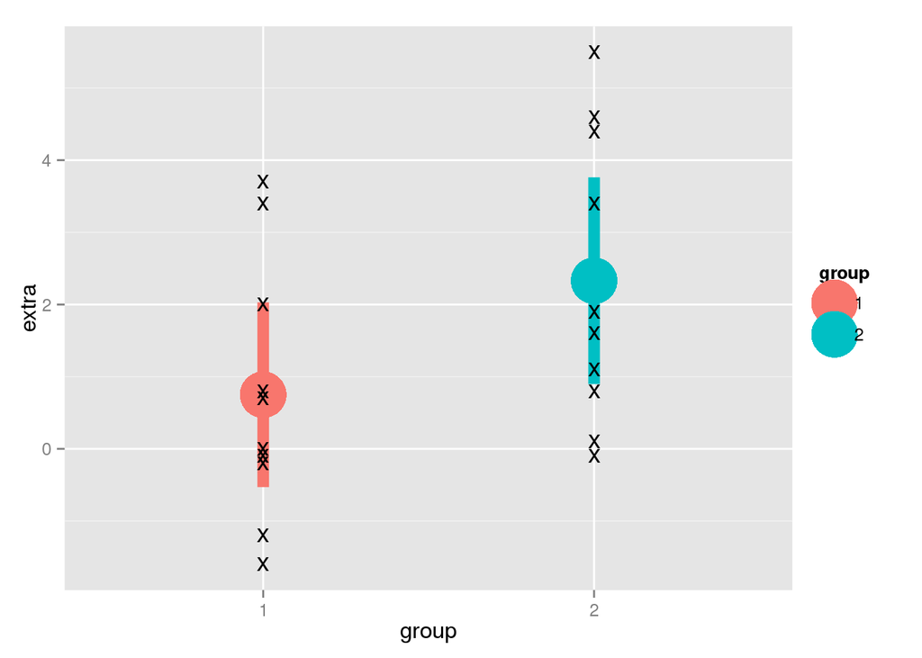

```r
ggplot(sleep, aes(x=group, y=extra, colour=group)) +
  stat_summary(fun.data="mean_cl_normal", size=3) +
  geom_point(colour='black', shape='x', size=5)
```

Notice that I have adjusted the size and type of the symbols using parameter size and shape. I have also overrided the default colour for the crosses by specifying the parameter colour=‘black’.

I could add some more information and eye candy.

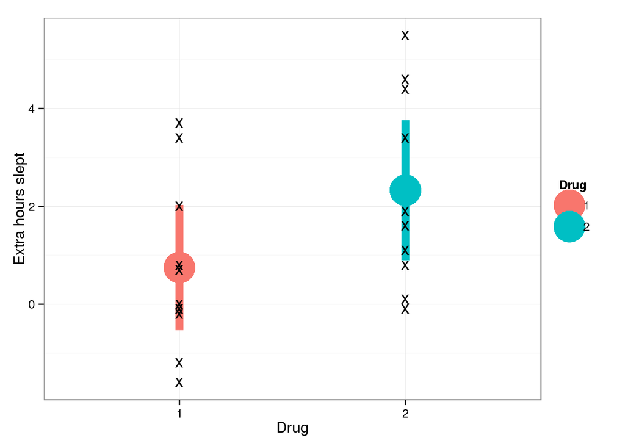

```r
ggplot(sleep, aes(x=group, y=extra, colour=group)) +
  stat_summary(fun.data="mean_cl_normal", size=3) +
  geom_point(colour='black', shape='x', size=5) +
  xlab("Drug") +
  ylab("Extra hours slept") +
  scale_colour_discrete(name="Drug") +
  theme_bw()
```